# Informatics Technology for Cancer Research (ITCR): Documentation and Usability

Candace Savonen

2021-04-14

# About this Course

This course is part of a series of courses for the Informatics Technology for Cancer Research (ITCR) called the Informatics Technology for Cancer Research Education Resource. This material was created by the ITCR Training Network (ITN) which is a collaborative effort of researchers around the United States to support cancer informatics and data science training through resources, technology, and events. Our courses feature tools developed by ITCR Investigators and make it easier for principal investigators, scientists, and analysts to integrate cancer informatics into their workflows. Please see our website at https://www.itcrtraining.org/ for more information.

# Introduction

Cancer datasets are plentiful, complicated, and hold information that may be critical for the next research advancements. In order to use these data to their full potential, researchers are dependent on the specialized data tools that are continually being published and developed. Bioinformatics tools can often be unfriendly to their users, who often have little to no background in programming (Bolchini et al. 2008). The usability and quality of the documentation of a tool can be a major factor in how efficiently a researcher is able to obtain useful findings for the next steps of their research.

## Motivation

Increasing the usability and quality of documentation for a tool is not only helpful for the researcher users, but also for the developers themselves – the many hours of work put into the product will have a higher impact if the tool is usable by the target user community. Even the most well-programmed tool will be overlooked by the user community if there is little to no user-friendly documentation.

### Target Audience

The course is intended for cancer informatics tool developers, particularly those creating tools as a part of the [Informatics Technology Cancer Research](https://itcr.cancer.gov/informatics-tools).

### Curriculum

The curriculum for this course will cover the basics of:

- Understanding why usability and documentation is vital
- Identifying your user community
- Building documentation and tutorials to maximize the usability of developed tools
- Obtaining feedback from your users

The course includes a hands-on exercises with templates for building documentation and tutorials for cancer informatics tools. Individuals who take this course are encouraged to use these templates as they follow along with the course material to help increase the usability of their informatics tool.

# What does good documentation look like?

## Learning Objectives

This chapter will demonstrate how to:

- Identify major components common to good documentation
- Describe the purposes of components of good documentation

## Major components of good documentation

In this chapter we are going to cover the major aspects of a well-documented tool. In the subsequent chapters, we will talk about each of these components in more detail; providing relevant examples and tools.

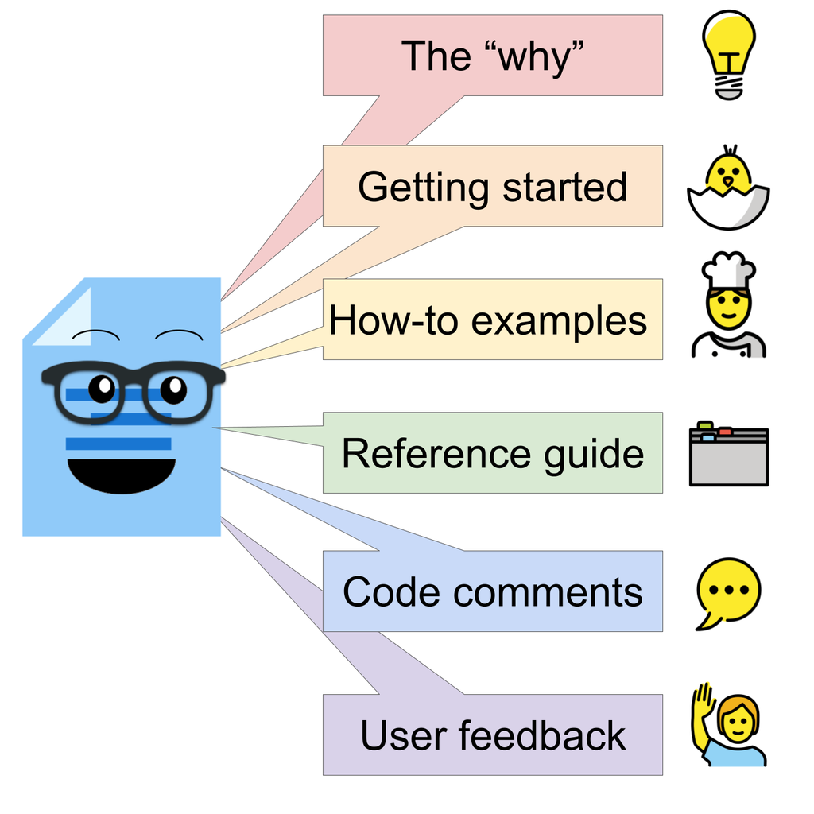

[^1]

### The ‘Why’

[figure not shown]

Before we get into the technical information in your documentation, the first thing that should be obvious to your user is why they should want to use your tool! What need of your users does your tool fulfill? If this is not glaringly obvious, users will move on without realizing how valuable your tool could be for their research!

#### Exercise: Write the why of your tool!

This should be the first thing your user sees on the main page of your tool. If it currently is not clear, take this time to workshop one or two sentences that explain the ‘why’ of your tool. As you craft this sentence, think about the needs of your user and how to summarize your tool’s purpose in a brief, punchy way. Stay away from jargon unless perhaps its jargon that you know your user will understand.

*Examples of tools with their why’s well-stated prominently on their web page:*

> Gene Set Enrichment Analysis (GSEA) is a computational method that determines whether an a priori defined set of genes shows statistically significant, concordant differences between two biological states (e.g. phenotypes).

[GSEA](http://www.gsea-msigdb.org/gsea/index.jsp)

> Salmon is a tool for wicked-fast transcript quantification from RNA-seq data. It requires a set of target transcripts (either from a reference or de-novo assembly) to quantify.

[Salmon](https://salmon.readthedocs.io/en/latest/salmon.html#using-salmon)

### Getting started

[figure not shown]

A Getting Started section will tell a new user the exact steps they need to “get started” – no extra steps or long-winded explanations. It will in the fewest but most exact steps as possible, tell the user how to: - Install the tool and any of its dependencies.  
- Run the most basic analysis with the tool.  
- Obtain some quick result.

It’s crucial that the steps here are simple and easy to follow or you risk losing new users before they even get going.

### How-to examples

[figure not shown]

A set of How-to examples will demonstrate step-by-step the most common uses after they have completed the Getting Started steps. - Every step is specifically provided by code (or by screenshots in the case of a GUI).  
- Any data needed to run the example is provided.  
- Common pitfalls and nuances of the tool that you may encounter when running the examples are explained in context.

### Reference guides

[figure not shown]

A reference guide is like a dictionary that a user can reference as questions arise. A user will likely have a specific question about a function, parameter, data type, or option and will want to be able to navigate to information about that item. Users who end up looking through your reference guide are likely a bit invested and may have already gone through the Getting Started section and/or How-to examples.

- All items are described in clear, non-jargon, language.
- The items are searchable or at least can be easily visually scanned.
- All options and defaults are explained and linked to more information where appropriate.

### Code comments

[figure not shown]

Comments in your source code are also a part of documentation – and likely the first part of the documentation you worked on! In most instances, if your tools is functioning fine, code will probably only be looked at by advanced and/or the most invested users. But also recall that documentation is not only for your user but for future you and existing or potential collaborators.

### User feedback mechanism

[figure not shown]

Try as you might, you will not be able to predict every scenario that a user may engage with your tool. Your user may encounter errors or quirks that you did not forsee but that would be helpful for you to know about. Your documentation should direct your users where they should send any comments or concerns. You should also make sure that this feedback method is something you can check up on and respond to regularly.

## The documentation templates for this course

We encourage you to create these pieces of documentation we will further discuss in the rest of this course!

We have a folder of template markdown files that you can use as-is in your code repository or have them rendered nicely as a [read-the-docs site](https://docs.readthedocs.io/en/stable/). Here’s a a quick preview of this folder’s contents (which we will cover in more depth in the upcoming chapters).

```
templates/
├── well_documented_checklist.md
├── getting_started_template.md
├── how_to_examples_examples.md
└── reference_guide_template.md
```

### Well-documented checklist

This document has a checklist that summarizes the major aspects that should be included in a tools’ documentation. We recommend using it to evaluate the documentation for an existing tool and identify any gaps you may need to address, or as a to-do list for creating new documentation that you can check off as you follow along with this course.

## How to use the templates folder

There are two options we suggest for creating documentation as you follow along with this course.

**Option 1)** Use these template markdowns essentially as they are (after you fill them in) and add them to an existing repository. (This is the less-work option).  
*Pros*: Is easier and quicker. *Cons*: Is not as user-friendly as option 2.

**Option 2)** Clone a repository with these templates and set up a MkDocs github pages site. (Slightly more work, but a very nice end result).  
*Pros*: This format of documentation sites are easy to navigate and likely familiar to your user.  
*Cons*: Will require more Github and `mkdocs` package knowledge to get this set up.

### Steps for Option 2) Creating a MkDocs site with Github pages

#### Using our template doc repository

- Go to our [template documentation repository](https://github.com/jhudsl/itcr-template-documentation).
- Click `Use this Template` to get started.
- Fill in the template with your own information.

On your computer’s command line:  
- [`git clone` your new repository](https://docs.github.com/en/github/creating-cloning-and-archiving-repositories/cloning-a-repository) you made from our template.  
- Navigate to your the root of your local version of this repository.  
- [Install mkdocs following their instructions.](https://www.mkdocs.org/#installation).

- Run `mkdocs new my-project`
- Run `mkdocs serve` to see a preview of your docs
- Edit the template pages we’ve provided in the `docs/` folder.
- As you make changes you can run `mkdocs build` and then `mkdocs serve` to see a preview.
- When you are ready to publish your documentation to its own website, run [`mkdocs gh-deploy`](https://www.mkdocs.org/user-guide/deploying-your-docs/), it will return the web address of your new site – go to that address and bask in the success of your newly made documentation!

# About the Authors

**Candace Savonen** is a Research Associate in the Department of Biostatistics at the Johns Hopkins Bloomberg School of Public Health. She creates bioinformatic education materials for cancer genomics, looking for ways to emphasize reproducibility and good data science practices. Her research background is in Neuroscience.

Bolchini, Davide, Anthony Finkelstein, Vito Perrone, and Sylvia Nagl. 2008. “Better Bioinformatics Through Usability Analysis.” *Bioinformatics* 25 (3): 406–12. https://doi.org/10.1093/bioinformatics/btn633.

[^1]: For all cartoons:  
    Avataars by https://getavataaars.com/.  
    Icons by https://thenounproject.com/ License CC BY-NC-ND 2.0.  
    Emojis by OpenMoji License: CC BY-SA 4.0.